# Trees

Babak RezaeeDaryakenari[^1], Sabanci University

Spring 2019

# Introduction

The idea of trees in statistical learning has similarity with decision trees models. Trees and its extensions have been used widely for modeling the prediction of outcome variables. Let’s start with revieiwng the advantages and disadvnatages of this method:

*Benefits:*

- Very good in capturing the interactions between the features of a models and non-linearities associations
- performs very well in handling categorical variables, with nice interpretation of the results
- relativelly faster than other machine learning algorithms
- does not require scaling x variables/features.

*Disadvantage:*

- Simple tree models do not lead to the best out-of-sample predicitve.

However, if we grow a good forest and bag/boost the models to combine the fits from different tree models, we can improve the prediction power.

# Regression Trees

It is much easier to explain the tree models using an example. Let’s start with the Boston housing data that we used before in $kNN$ section. Similarly, I want to predict median housing price in a neighborhood, ${\tt medv}$, using the ratio of low state housholds, ${\tt lstat}$.

```r
library(MASS)
attach(Boston)
n = nrow(Boston)

ddf = data.frame(lstat,medv)

# Sort the data here
oo=order(ddf$lstat)

ddf = ddf[oo,]


library(rpart)

m_tree=rpart(medv~lstat,data=ddf)

#plot the estimated tree

summary(m_tree)
```

```
## Call:
## rpart(formula = medv ~ lstat, data = ddf)
##   n= 506
##
##           CP nsplit rel error    xerror       xstd
## 1 0.44236500      0 1.0000000 1.0040065 0.08309246
## 2 0.15283400      1 0.5576350 0.5970776 0.04875541
## 3 0.06275014      2 0.4048010 0.4669553 0.04359431
## 4 0.01374053      3 0.3420509 0.4110652 0.04053712
## 5 0.01200979      4 0.3283103 0.3768981 0.03803593
## 6 0.01159492      5 0.3163005 0.3754366 0.03891651
## 7 0.01000000      6 0.3047056 0.3728933 0.03884789
##
## Variable importance
## lstat
##   100
##
## Node number 1: 506 observations,    complexity param=0.442365
##   mean=22.53281, MSE=84.41956
##   left son=2 (294 obs) right son=3 (212 obs)
##   Primary splits:
##       lstat < 9.725  to the right, improve=0.442365, (0 missing)
##
## Node number 2: 294 observations,    complexity param=0.06275014
##   mean=17.34354, MSE=23.83089
##   left son=4 (144 obs) right son=5 (150 obs)
##   Primary splits:
##       lstat < 16.085 to the right, improve=0.3825785, (0 missing)
##
## Node number 3: 212 observations,    complexity param=0.152834
##   mean=29.72925, MSE=79.31047
##   left son=6 (162 obs) right son=7 (50 obs)
##   Primary splits:
##       lstat < 4.65   to the right, improve=0.3882819, (0 missing)
##
## Node number 4: 144 observations,    complexity param=0.01374053
##   mean=14.26181, MSE=18.74458
##   left son=8 (75 obs) right son=9 (69 obs)
##   Primary splits:
##       lstat < 19.9   to the right, improve=0.2174498, (0 missing)
```

[output cut: 18 more lines]

```
##
## Node number 9: 69 observations
##   mean=16.36667, MSE=13.01729
##
## Node number 12: 134 observations
##   mean=25.84701, MSE=40.14324
##
## Node number 13: 28 observations
##   mean=30.47143, MSE=37.49776
##
## Node number 14: 32 observations
##   mean=37.31562, MSE=65.92382
##
## Node number 15: 18 observations
##   mean=43.98889, MSE=41.01765
```

```r
summary(ddf$medv)
```

```
##    Min. 1st Qu.  Median    Mean 3rd Qu.    Max.
##    5.00   17.02   21.20   22.53   25.00   50.00
```

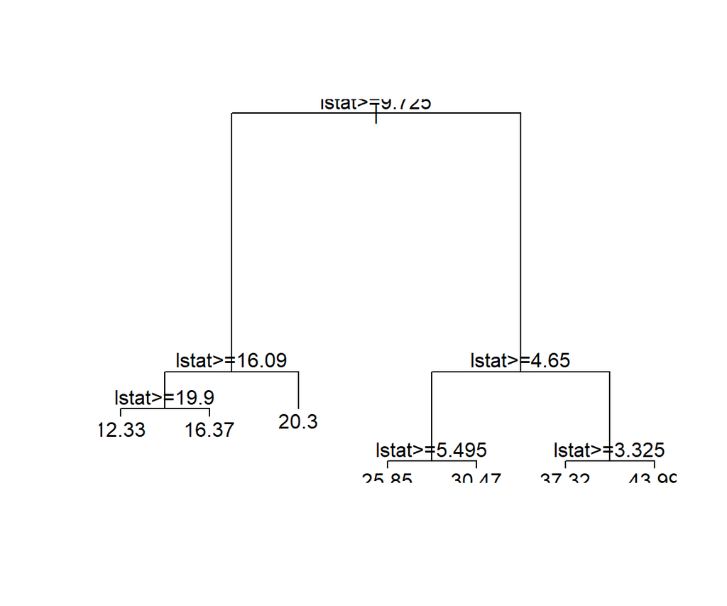

```r
plot(m_tree)

text(m_tree)
```

But, this plot does not often look good. Indeed, it usually is a mees! To plot a nice tree, I suggest using ${\tt rpart.plot}$ package.

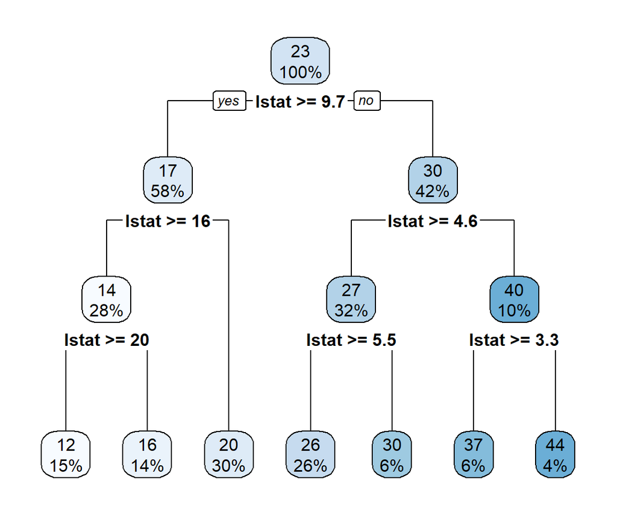

```r
library(rpart.plot)

rpart.plot(m_tree)
```

At each interior node, there is decision rule, $x>c$. If $x>c$, you should follow the branch on the left. This continues untill you reach a bottom/terminal node, which also is known as the leaf of the tree.

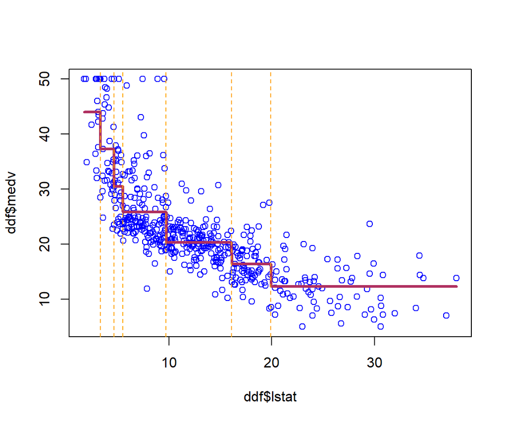

```r
plot(ddf$lstat,ddf$medv, col='blue')

lines(ddf$lstat,predict(m_tree,ddf),col='maroon',lwd=3)


for (i in m_tree$splits[,4] ){
abline(v=i, col="orange",lty=2)
}
```

The set of bottom nodes gives us a partition of the predictor $x$ space into disjoint regions. At right, the vertical lines display the partition. With just one x, this is just a set of intervals.

Within each region (interval) we compute the average of the $y$ values for the subset of training data in the region. This gives us the step function which is our $\hat{f}$. The $\bar{y}$ values are also printed at the bottom nodes. To predict, we just use the above step function estimation of f(x).

# A Tree with Two Explanatory Variables

Now, let’s estimate a tree model using two features: $x=(lstat, dis)$ and $y=medx$.

First, let’s take a look at scatter plot of these variables:

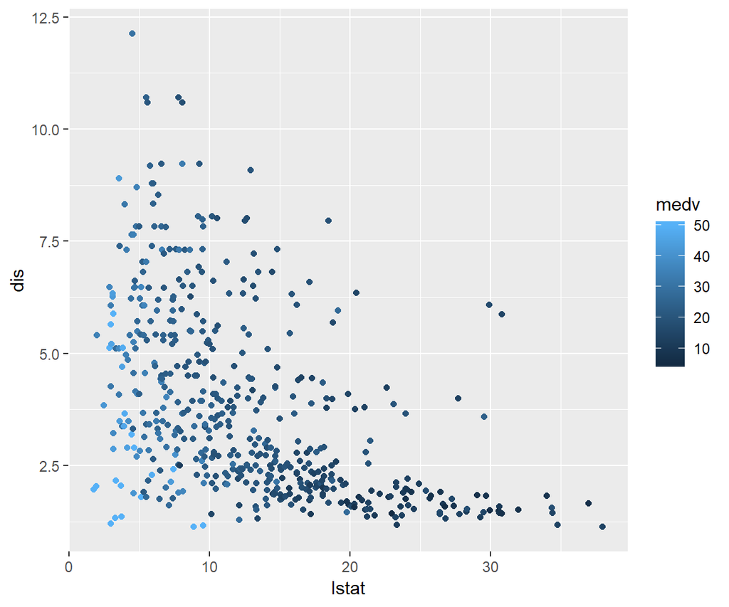

```r
attach(Boston)

ddf = data.frame(lstat,dis,medv)

# Sort the data here
oo=order(ddf$lstat)

ddf = ddf[oo,]

library(ggplot2)

ggplot(ddf, aes(lstat, dis, colour = medv)) + geom_point()
```

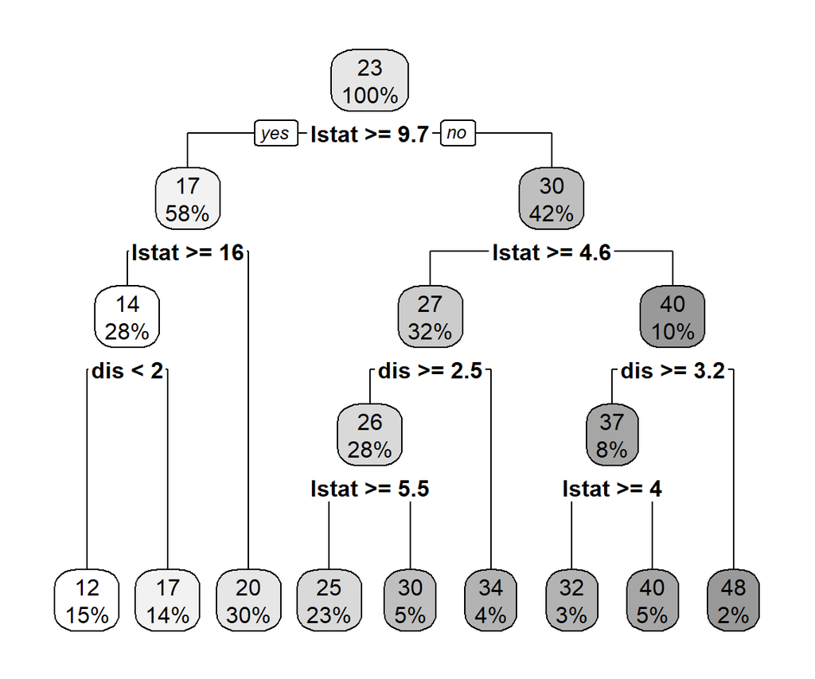

```r
m_tree2=rpart(medv~lstat+dis,data=ddf)


rpart.plot(m_tree2, box.palette = "Grays")
```

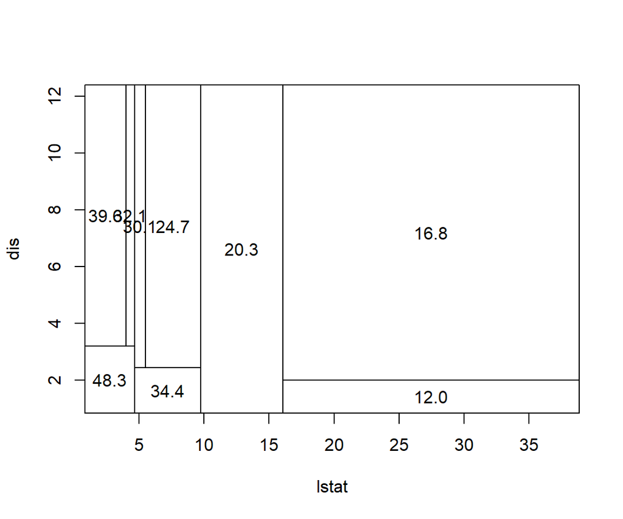

```r
library(tree)

m_tree2=tree(medv~lstat+dis,data=ddf)


partition.tree(m_tree2)
```

[^1]: Copyright 2019. This is an in-progress project, please do not cite or reproduce without my permission.